# Risk Factor Analysis

## Outcome Variable

**Outcome Variable:** sstunted

## Predictor Variables

**Intervention Variable:** tr

**Adjustment Set:**

unadjusted

## Stratifying Variables

The analysis was stratified on these variable(s):

- agecat
- studyid
- country
- intXmbmi

## Data Summary

| agecat | studyid | country | intXmbmi | sstunted | n_cell | n |
| --- | --- | --- | --- | --- | --- | --- |
| Birth | iLiNS_DYADM_LNS | MALAWI | Underweight_Birth | 0 | 0 | 1 |
| Birth | iLiNS_DYADM_LNS | MALAWI | Underweight_Birth | 1 | 1 | 1 |
| Birth | ki1000125-AgaKhanUniv | PAKISTAN | Overweight or Obese_Birth | 0 | 4 | 4 |
| Birth | ki1000125-AgaKhanUniv | PAKISTAN | Overweight or Obese_Birth | 1 | 0 | 4 |
| Birth | ki1000304b-SAS-CompFeed | INDIA | Normal weight_Birth | 0 | 53 | 60 |
| Birth | ki1000304b-SAS-CompFeed | INDIA | Normal weight_Birth | 1 | 7 | 60 |
| Birth | ki1000304b-SAS-CompFeed | INDIA | Underweight_Birth | 0 | 24 | 27 |
| Birth | ki1000304b-SAS-CompFeed | INDIA | Underweight_Birth | 1 | 3 | 27 |
| Birth | ki1000304b-SAS-CompFeed | INDIA | Overweight or Obese_Birth | 0 | 2 | 2 |
| Birth | ki1000304b-SAS-CompFeed | INDIA | Overweight or Obese_Birth | 1 | 0 | 2 |
| Birth | ki1119695-PROBIT | BELARUS | Normal weight_Birth | 0 | 8145 | 8149 |
| Birth | ki1119695-PROBIT | BELARUS | Normal weight_Birth | 1 | 4 | 8149 |
| Birth | ki1119695-PROBIT | BELARUS | Underweight_Birth | 0 | 523 | 523 |
| Birth | ki1119695-PROBIT | BELARUS | Underweight_Birth | 1 | 0 | 523 |
| Birth | ki1119695-PROBIT | BELARUS | Overweight or Obese_Birth | 0 | 5050 | 5051 |
| Birth | ki1119695-PROBIT | BELARUS | Overweight or Obese_Birth | 1 | 1 | 5051 |
| Birth | ki1126311-ZVITAMBO | ZIMBABWE | Normal weight_Birth | 0 | 6394 | 6598 |
| Birth | ki1126311-ZVITAMBO | ZIMBABWE | Normal weight_Birth | 1 | 204 | 6598 |
| Birth | ki1126311-ZVITAMBO | ZIMBABWE | Underweight_Birth | 0 | 484 | 510 |
| Birth | ki1126311-ZVITAMBO | ZIMBABWE | Underweight_Birth | 1 | 26 | 510 |
| Birth | ki1126311-ZVITAMBO | ZIMBABWE | Overweight or Obese_Birth | 0 | 2473 | 2526 |
| Birth | ki1126311-ZVITAMBO | ZIMBABWE | Overweight or Obese_Birth | 1 | 53 | 2526 |
| Birth | ki1148112-iLiNS-DYAD-M | MALAWI | Underweight_Birth | 0 | 0 | 1 |
| Birth | ki1148112-iLiNS-DYAD-M | MALAWI | Underweight_Birth | 1 | 1 | 1 |
| 6 months | iLiNS_DYADM_LNS | MALAWI | Normal weight_6 months | 0 | 2 | 2 |
| 6 months | iLiNS_DYADM_LNS | MALAWI | Normal weight_6 months | 1 | 0 | 2 |
| 6 months | iLiNS_DYADM_LNS | MALAWI | Underweight_6 months | 0 | 1 | 1 |
| 6 months | iLiNS_DYADM_LNS | MALAWI | Underweight_6 months | 1 | 0 | 1 |
| 6 months | ki1000110-WASH-Bangladesh | BANGLADESH | Normal weight_6 months | 0 | 420 | 432 |
| 6 months | ki1000110-WASH-Bangladesh | BANGLADESH | Normal weight_6 months | 1 | 12 | 432 |

[output cut: 100 more lines]

The following strata were considered:

- agecat: 24 months, studyid: ki1000110-WASH-Bangladesh, country: BANGLADESH, intXmbmi: Normal weight_24 months
- agecat: 24 months, studyid: ki1000110-WASH-Bangladesh, country: BANGLADESH, intXmbmi: Overweight or Obese_24 months
- agecat: 24 months, studyid: ki1000110-WASH-Bangladesh, country: BANGLADESH, intXmbmi: Underweight_24 months
- agecat: 24 months, studyid: ki1017093b-PROVIDE, country: BANGLADESH, intXmbmi: Normal weight_24 months
- agecat: 24 months, studyid: ki1066203-TanzaniaChild2, country: TANZANIA, UNITED REPUBLIC OF, intXmbmi: Normal weight_24 months
- agecat: 24 months, studyid: ki1066203-TanzaniaChild2, country: TANZANIA, UNITED REPUBLIC OF, intXmbmi: Overweight or Obese_24 months
- agecat: 24 months, studyid: ki1112895-Burkina Faso Zn, country: BURKINA FASO, intXmbmi: Normal weight_24 months
- agecat: 24 months, studyid: ki1112895-Burkina Faso Zn, country: BURKINA FASO, intXmbmi: Overweight or Obese_24 months
- agecat: 24 months, studyid: ki1112895-Burkina Faso Zn, country: BURKINA FASO, intXmbmi: Underweight_24 months
- agecat: 24 months, studyid: ki1119695-PROBIT, country: BELARUS, intXmbmi: Normal weight_24 months
- agecat: 24 months, studyid: ki1119695-PROBIT, country: BELARUS, intXmbmi: Overweight or Obese_24 months
- agecat: 24 months, studyid: ki1119695-PROBIT, country: BELARUS, intXmbmi: Underweight_24 months
- agecat: 24 months, studyid: ki1126311-ZVITAMBO, country: ZIMBABWE, intXmbmi: Normal weight_24 months
- agecat: 24 months, studyid: ki1126311-ZVITAMBO, country: ZIMBABWE, intXmbmi: Overweight or Obese_24 months
- agecat: 24 months, studyid: ki1126311-ZVITAMBO, country: ZIMBABWE, intXmbmi: Underweight_24 months
- agecat: 24 months, studyid: ki1148112-iLiNS-DOSE, country: MALAWI, intXmbmi: Normal weight_24 months
- agecat: 24 months, studyid: ki1148112-iLiNS-DOSE, country: MALAWI, intXmbmi: Overweight or Obese_24 months
- agecat: 24 months, studyid: ki1148112-iLiNS-DOSE, country: MALAWI, intXmbmi: Underweight_24 months
- agecat: 24 months, studyid: ki1148112-LCNI-5, country: MALAWI, intXmbmi: Normal weight_24 months
- agecat: 24 months, studyid: ki1148112-LCNI-5, country: MALAWI, intXmbmi: Overweight or Obese_24 months
- agecat: 24 months, studyid: ki1148112-LCNI-5, country: MALAWI, intXmbmi: Underweight_24 months
- agecat: 6 months, studyid: iLiNS_DYADM_LNS, country: MALAWI, intXmbmi: Normal weight_6 months
- agecat: 6 months, studyid: iLiNS_DYADM_LNS, country: MALAWI, intXmbmi: Underweight_6 months
- agecat: 6 months, studyid: ki1000110-WASH-Bangladesh, country: BANGLADESH, intXmbmi: Normal weight_6 months
- agecat: 6 months, studyid: ki1000110-WASH-Bangladesh, country: BANGLADESH, intXmbmi: Overweight or Obese_6 months
- agecat: 6 months, studyid: ki1000110-WASH-Bangladesh, country: BANGLADESH, intXmbmi: Underweight_6 months
- agecat: 6 months, studyid: ki1000125-AgaKhanUniv, country: PAKISTAN, intXmbmi: Overweight or Obese_6 months
- agecat: 6 months, studyid: ki1000304b-SAS-CompFeed, country: INDIA, intXmbmi: Normal weight_6 months
- agecat: 6 months, studyid: ki1000304b-SAS-CompFeed, country: INDIA, intXmbmi: Overweight or Obese_6 months
- agecat: 6 months, studyid: ki1000304b-SAS-CompFeed, country: INDIA, intXmbmi: Underweight_6 months
- agecat: 6 months, studyid: ki1017093b-PROVIDE, country: BANGLADESH, intXmbmi: Normal weight_6 months
- agecat: 6 months, studyid: ki1017093b-PROVIDE, country: BANGLADESH, intXmbmi: Overweight or Obese_6 months
- agecat: 6 months, studyid: ki1017093b-PROVIDE, country: BANGLADESH, intXmbmi: Underweight_6 months
- agecat: 6 months, studyid: ki1066203-TanzaniaChild2, country: TANZANIA, UNITED REPUBLIC OF, intXmbmi: Normal weight_6 months
- agecat: 6 months, studyid: ki1066203-TanzaniaChild2, country: TANZANIA, UNITED REPUBLIC OF, intXmbmi: Overweight or Obese_6 months
- agecat: 6 months, studyid: ki1066203-TanzaniaChild2, country: TANZANIA, UNITED REPUBLIC OF, intXmbmi: Underweight_6 months
- agecat: 6 months, studyid: ki1112895-Burkina Faso Zn, country: BURKINA FASO, intXmbmi: Normal weight_6 months
- agecat: 6 months, studyid: ki1112895-Burkina Faso Zn, country: BURKINA FASO, intXmbmi: Overweight or Obese_6 months
- agecat: 6 months, studyid: ki1112895-Burkina Faso Zn, country: BURKINA FASO, intXmbmi: Underweight_6 months
- agecat: 6 months, studyid: ki1119695-PROBIT, country: BELARUS, intXmbmi: Normal weight_6 months
- agecat: 6 months, studyid: ki1119695-PROBIT, country: BELARUS, intXmbmi: Overweight or Obese_6 months
- agecat: 6 months, studyid: ki1119695-PROBIT, country: BELARUS, intXmbmi: Underweight_6 months
- agecat: 6 months, studyid: ki1126311-ZVITAMBO, country: ZIMBABWE, intXmbmi: Normal weight_6 months
- agecat: 6 months, studyid: ki1126311-ZVITAMBO, country: ZIMBABWE, intXmbmi: Overweight or Obese_6 months
- agecat: 6 months, studyid: ki1126311-ZVITAMBO, country: ZIMBABWE, intXmbmi: Underweight_6 months
- agecat: 6 months, studyid: ki1148112-iLiNS-DOSE, country: MALAWI, intXmbmi: Normal weight_6 months
- agecat: 6 months, studyid: ki1148112-iLiNS-DOSE, country: MALAWI, intXmbmi: Overweight or Obese_6 months
- agecat: 6 months, studyid: ki1148112-iLiNS-DOSE, country: MALAWI, intXmbmi: Underweight_6 months
- agecat: 6 months, studyid: ki1148112-iLiNS-DYAD-M, country: MALAWI, intXmbmi: Normal weight_6 months
- agecat: 6 months, studyid: ki1148112-iLiNS-DYAD-M, country: MALAWI, intXmbmi: Underweight_6 months
- agecat: 6 months, studyid: ki1148112-LCNI-5, country: MALAWI, intXmbmi: Normal weight_6 months
- agecat: 6 months, studyid: ki1148112-LCNI-5, country: MALAWI, intXmbmi: Overweight or Obese_6 months
- agecat: 6 months, studyid: ki1148112-LCNI-5, country: MALAWI, intXmbmi: Underweight_6 months
- agecat: Birth, studyid: iLiNS_DYADM_LNS, country: MALAWI, intXmbmi: Underweight_Birth
- agecat: Birth, studyid: ki1000125-AgaKhanUniv, country: PAKISTAN, intXmbmi: Overweight or Obese_Birth
- agecat: Birth, studyid: ki1000304b-SAS-CompFeed, country: INDIA, intXmbmi: Normal weight_Birth
- agecat: Birth, studyid: ki1000304b-SAS-CompFeed, country: INDIA, intXmbmi: Overweight or Obese_Birth
- agecat: Birth, studyid: ki1000304b-SAS-CompFeed, country: INDIA, intXmbmi: Underweight_Birth
- agecat: Birth, studyid: ki1119695-PROBIT, country: BELARUS, intXmbmi: Normal weight_Birth
- agecat: Birth, studyid: ki1119695-PROBIT, country: BELARUS, intXmbmi: Overweight or Obese_Birth
- agecat: Birth, studyid: ki1119695-PROBIT, country: BELARUS, intXmbmi: Underweight_Birth
- agecat: Birth, studyid: ki1126311-ZVITAMBO, country: ZIMBABWE, intXmbmi: Normal weight_Birth
- agecat: Birth, studyid: ki1126311-ZVITAMBO, country: ZIMBABWE, intXmbmi: Overweight or Obese_Birth
- agecat: Birth, studyid: ki1126311-ZVITAMBO, country: ZIMBABWE, intXmbmi: Underweight_Birth
- agecat: Birth, studyid: ki1148112-iLiNS-DYAD-M, country: MALAWI, intXmbmi: Underweight_Birth

### Dropped Strata

Some strata were dropped due to rare outcomes:

- agecat: Birth, studyid: iLiNS_DYADM_LNS, country: MALAWI, intXmbmi: Underweight_Birth
- agecat: Birth, studyid: ki1000125-AgaKhanUniv, country: PAKISTAN, intXmbmi: Overweight or Obese_Birth
- agecat: Birth, studyid: ki1000304b-SAS-CompFeed, country: INDIA, intXmbmi: Underweight_Birth
- agecat: Birth, studyid: ki1000304b-SAS-CompFeed, country: INDIA, intXmbmi: Overweight or Obese_Birth
- agecat: Birth, studyid: ki1119695-PROBIT, country: BELARUS, intXmbmi: Normal weight_Birth
- agecat: Birth, studyid: ki1119695-PROBIT, country: BELARUS, intXmbmi: Underweight_Birth
- agecat: Birth, studyid: ki1119695-PROBIT, country: BELARUS, intXmbmi: Overweight or Obese_Birth
- agecat: Birth, studyid: ki1148112-iLiNS-DYAD-M, country: MALAWI, intXmbmi: Underweight_Birth
- agecat: 6 months, studyid: iLiNS_DYADM_LNS, country: MALAWI, intXmbmi: Normal weight_6 months
- agecat: 6 months, studyid: iLiNS_DYADM_LNS, country: MALAWI, intXmbmi: Underweight_6 months
- agecat: 6 months, studyid: ki1000110-WASH-Bangladesh, country: BANGLADESH, intXmbmi: Overweight or Obese_6 months
- agecat: 6 months, studyid: ki1000304b-SAS-CompFeed, country: INDIA, intXmbmi: Overweight or Obese_6 months
- agecat: 6 months, studyid: ki1017093b-PROVIDE, country: BANGLADESH, intXmbmi: Normal weight_6 months
- agecat: 6 months, studyid: ki1017093b-PROVIDE, country: BANGLADESH, intXmbmi: Underweight_6 months
- agecat: 6 months, studyid: ki1017093b-PROVIDE, country: BANGLADESH, intXmbmi: Overweight or Obese_6 months
- agecat: 6 months, studyid: ki1066203-TanzaniaChild2, country: TANZANIA, UNITED REPUBLIC OF, intXmbmi: Underweight_6 months
- agecat: 6 months, studyid: ki1112895-Burkina Faso Zn, country: BURKINA FASO, intXmbmi: Underweight_6 months
- agecat: 6 months, studyid: ki1112895-Burkina Faso Zn, country: BURKINA FASO, intXmbmi: Overweight or Obese_6 months
- agecat: 6 months, studyid: ki1148112-iLiNS-DYAD-M, country: MALAWI, intXmbmi: Normal weight_6 months
- agecat: 6 months, studyid: ki1148112-iLiNS-DYAD-M, country: MALAWI, intXmbmi: Underweight_6 months
- agecat: 6 months, studyid: ki1148112-LCNI-5, country: MALAWI, intXmbmi: Overweight or Obese_6 months
- agecat: 24 months, studyid: ki1017093b-PROVIDE, country: BANGLADESH, intXmbmi: Normal weight_24 months
- agecat: 24 months, studyid: ki1066203-TanzaniaChild2, country: TANZANIA, UNITED REPUBLIC OF, intXmbmi: Normal weight_24 months
- agecat: 24 months, studyid: ki1066203-TanzaniaChild2, country: TANZANIA, UNITED REPUBLIC OF, intXmbmi: Overweight or Obese_24 months
- agecat: 24 months, studyid: ki1119695-PROBIT, country: BELARUS, intXmbmi: Underweight_24 months
- agecat: 24 months, studyid: ki1126311-ZVITAMBO, country: ZIMBABWE, intXmbmi: Underweight_24 months
- agecat: 24 months, studyid: ki1126311-ZVITAMBO, country: ZIMBABWE, intXmbmi: Overweight or Obese_24 months
- agecat: 24 months, studyid: ki1148112-LCNI-5, country: MALAWI, intXmbmi: Overweight or Obese_24 months

## Methods Detail

We’re interested in the causal parameters $E[Y_a]$ for all values of $a \in \mathcal{A}$. These parameters represent the mean outcome if, possibly contrary to fact, we intervened to set all units to have $A=a$. Under the randomization and positivity assumptions, these are identified by the statistical parameters $\psi_a=E_W[E_{Y|A,W}(Y|A=a,W)]$. In addition, we’re interested in the mean of $Y$, $E[Y]$ under no intervention (the observed mean). We will estimate these parameters by using SuperLearner to fit the relevant likelihood factors – $E_{Y|A,W}(Y|A=a,W)$ and $p(A=a|W)$, and then updating our likelihood fit using a joint TMLE.

For unadjusted analyses ($W=\{\}$), initial likelihoods were estimated using Lrnr_glm to estimate the simple $E(Y|A)$ and Lrnr_mean to estimate $p(A)$. For adjusted analyses, a small library containing Lrnr_glmnet, Lrnr_xgboost, and Lrnr_mean was used.

Having estimated these parameters, we will then use the delta method to estimate relative risks and attributable risks relative to a prespecified baseline level of $A$.

[output not shown]

# Results Detail

## Results Plots

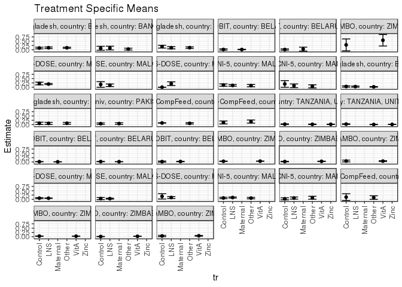

[figure not shown]

[figure not shown]

[figure not shown]

## Results Table

### Parameter: TSM

| agecat | studyid | country | intXmbmi | intervention_level | baseline_level | estimate | ci_lower | ci_upper |
| --- | --- | --- | --- | --- | --- | --- | --- | --- |
| Birth | ki1000304b-SAS-CompFeed | INDIA | Normal weight_Birth | Control | NA | 0.1290323 | -0.0691503 | 0.3272148 |
| Birth | ki1000304b-SAS-CompFeed | INDIA | Normal weight_Birth | Other | NA | 0.1034483 | -0.0004177 | 0.2073142 |
| Birth | ki1126311-ZVITAMBO | ZIMBABWE | Normal weight_Birth | Control | NA | 0.0346294 | 0.0257958 | 0.0434630 |
| Birth | ki1126311-ZVITAMBO | ZIMBABWE | Normal weight_Birth | VitA | NA | 0.0296850 | 0.0249577 | 0.0344123 |
| Birth | ki1126311-ZVITAMBO | ZIMBABWE | Underweight_Birth | Control | NA | 0.0438597 | 0.0062313 | 0.0814880 |
| Birth | ki1126311-ZVITAMBO | ZIMBABWE | Underweight_Birth | VitA | NA | 0.0530303 | 0.0309372 | 0.0751234 |
| Birth | ki1126311-ZVITAMBO | ZIMBABWE | Overweight or Obese_Birth | Control | NA | 0.0112360 | 0.0029577 | 0.0195143 |
| Birth | ki1126311-ZVITAMBO | ZIMBABWE | Overweight or Obese_Birth | VitA | NA | 0.0241724 | 0.0172706 | 0.0310741 |
| 6 months | ki1000110-WASH-Bangladesh | BANGLADESH | Normal weight_6 months | Control | NA | 0.0400000 | 0.0015482 | 0.0784518 |
| 6 months | ki1000110-WASH-Bangladesh | BANGLADESH | Normal weight_6 months | LNS | NA | 0.0333333 | 0.0011791 | 0.0654876 |
| 6 months | ki1000110-WASH-Bangladesh | BANGLADESH | Normal weight_6 months | Other | NA | 0.0188679 | 0.0005317 | 0.0372041 |
| 6 months | ki1000110-WASH-Bangladesh | BANGLADESH | Underweight_6 months | Control | NA | 0.0714286 | 0.0038142 | 0.1390430 |
| 6 months | ki1000110-WASH-Bangladesh | BANGLADESH | Underweight_6 months | LNS | NA | 0.0666667 | 0.0033983 | 0.1299350 |
| 6 months | ki1000110-WASH-Bangladesh | BANGLADESH | Underweight_6 months | Other | NA | 0.0752688 | 0.0215207 | 0.1290170 |
| 6 months | ki1000125-AgaKhanUniv | PAKISTAN | Overweight or Obese_6 months | Control | NA | 0.0520833 | 0.0075146 | 0.0966521 |
| 6 months | ki1000125-AgaKhanUniv | PAKISTAN | Overweight or Obese_6 months | Maternal | NA | 0.0568182 | 0.0083193 | 0.1053170 |
| 6 months | ki1000304b-SAS-CompFeed | INDIA | Normal weight_6 months | Control | NA | 0.0939227 | 0.0827428 | 0.1051025 |
| 6 months | ki1000304b-SAS-CompFeed | INDIA | Normal weight_6 months | Other | NA | 0.0697674 | 0.0306973 | 0.1088376 |
| 6 months | ki1000304b-SAS-CompFeed | INDIA | Underweight_6 months | Control | NA | 0.1212121 | 0.0366082 | 0.2058161 |
| 6 months | ki1000304b-SAS-CompFeed | INDIA | Underweight_6 months | Other | NA | 0.1746032 | 0.0815946 | 0.2676118 |
| 6 months | ki1066203-TanzaniaChild2 | TANZANIA, UNITED REPUBLIC OF | Normal weight_6 months | Control | NA | 0.0218341 | 0.0028950 | 0.0407731 |
| 6 months | ki1066203-TanzaniaChild2 | TANZANIA, UNITED REPUBLIC OF | Normal weight_6 months | Other | NA | 0.0142857 | -0.0017733 | 0.0303448 |
| 6 months | ki1066203-TanzaniaChild2 | TANZANIA, UNITED REPUBLIC OF | Normal weight_6 months | Zinc | NA | 0.0144928 | 0.0029739 | 0.0260116 |
| 6 months | ki1066203-TanzaniaChild2 | TANZANIA, UNITED REPUBLIC OF | Overweight or Obese_6 months | Control | NA | 0.0265957 | 0.0035814 | 0.0496101 |
| 6 months | ki1066203-TanzaniaChild2 | TANZANIA, UNITED REPUBLIC OF | Overweight or Obese_6 months | Other | NA | 0.0052632 | -0.0050318 | 0.0155581 |
| 6 months | ki1066203-TanzaniaChild2 | TANZANIA, UNITED REPUBLIC OF | Overweight or Obese_6 months | Zinc | NA | 0.0098280 | 0.0002381 | 0.0194179 |
| 6 months | ki1119695-PROBIT | BELARUS | Normal weight_6 months | Control | NA | 0.0151256 | 0.0073826 | 0.0228686 |
| 6 months | ki1119695-PROBIT | BELARUS | Normal weight_6 months | Maternal | NA | 0.0091514 | 0.0047456 | 0.0135573 |
| 6 months | ki1119695-PROBIT | BELARUS | Underweight_6 months | Control | NA | 0.0179372 | -0.0147005 | 0.0505750 |
| 6 months | ki1119695-PROBIT | BELARUS | Underweight_6 months | Maternal | NA | 0.0251046 | 0.0097318 | 0.0404774 |
| 6 months | ki1119695-PROBIT | BELARUS | Overweight or Obese_6 months | Control | NA | 0.0205633 | 0.0116520 | 0.0294745 |
| 6 months | ki1119695-PROBIT | BELARUS | Overweight or Obese_6 months | Maternal | NA | 0.0146319 | 0.0069908 | 0.0222730 |
| 6 months | ki1126311-ZVITAMBO | ZIMBABWE | Normal weight_6 months | Control | NA | 0.0396476 | 0.0282943 | 0.0510009 |
| 6 months | ki1126311-ZVITAMBO | ZIMBABWE | Normal weight_6 months | VitA | NA | 0.0454411 | 0.0384284 | 0.0524538 |
| 6 months | ki1126311-ZVITAMBO | ZIMBABWE | Underweight_6 months | Control | NA | 0.0547945 | 0.0025114 | 0.1070777 |
| 6 months | ki1126311-ZVITAMBO | ZIMBABWE | Underweight_6 months | VitA | NA | 0.0490566 | 0.0230134 | 0.0750998 |
| 6 months | ki1126311-ZVITAMBO | ZIMBABWE | Overweight or Obese_6 months | Control | NA | 0.0230415 | 0.0089220 | 0.0371609 |
| 6 months | ki1126311-ZVITAMBO | ZIMBABWE | Overweight or Obese_6 months | VitA | NA | 0.0356877 | 0.0257708 | 0.0456047 |
| 6 months | ki1148112-iLiNS-DOSE | MALAWI | Normal weight_6 months | Control | NA | 0.0680000 | 0.0367837 | 0.0992163 |
| 6 months | ki1148112-iLiNS-DOSE | MALAWI | Normal weight_6 months | LNS | NA | 0.0643411 | 0.0509475 | 0.0777347 |
| 6 months | ki1148112-iLiNS-DOSE | MALAWI | Underweight_6 months | Control | NA | 0.1739130 | 0.0184362 | 0.3293899 |
| 6 months | ki1148112-iLiNS-DOSE | MALAWI | Underweight_6 months | LNS | NA | 0.1061947 | 0.0491803 | 0.1632091 |
| 6 months | ki1148112-iLiNS-DOSE | MALAWI | Overweight or Obese_6 months | Control | NA | 0.0444444 | -0.0158907 | 0.1047796 |
| 6 months | ki1148112-iLiNS-DOSE | MALAWI | Overweight or Obese_6 months | LNS | NA | 0.0402010 | 0.0128532 | 0.0675488 |
| 6 months | ki1148112-LCNI-5 | MALAWI | Normal weight_6 months | Control | NA | 0.0792683 | 0.0378896 | 0.1206469 |
| 6 months | ki1148112-LCNI-5 | MALAWI | Normal weight_6 months | LNS | NA | 0.1044776 | 0.0716976 | 0.1372576 |
| 6 months | ki1148112-LCNI-5 | MALAWI | Normal weight_6 months | Other | NA | 0.0723684 | 0.0311471 | 0.1135898 |
| 6 months | ki1148112-LCNI-5 | MALAWI | Underweight_6 months | Control | NA | 0.0303030 | -0.0283857 | 0.0889918 |
| 6 months | ki1148112-LCNI-5 | MALAWI | Underweight_6 months | LNS | NA | 0.0735294 | 0.0112789 | 0.1357799 |
| 6 months | ki1148112-LCNI-5 | MALAWI | Underweight_6 months | Other | NA | 0.0909091 | 0.0056714 | 0.1761468 |
| 24 months | ki1000110-WASH-Bangladesh | BANGLADESH | Normal weight_24 months | Control | NA | 0.1030303 | 0.0566121 | 0.1494485 |
| 24 months | ki1000110-WASH-Bangladesh | BANGLADESH | Normal weight_24 months | LNS | NA | 0.1186441 | 0.0709712 | 0.1663169 |
| 24 months | ki1000110-WASH-Bangladesh | BANGLADESH | Normal weight_24 months | Other | NA | 0.1176471 | 0.0842016 | 0.1510925 |
| 24 months | ki1000110-WASH-Bangladesh | BANGLADESH | Underweight_24 months | Control | NA | 0.1829268 | 0.0991398 | 0.2667138 |
| 24 months | ki1000110-WASH-Bangladesh | BANGLADESH | Underweight_24 months | LNS | NA | 0.1200000 | 0.0562256 | 0.1837744 |
| 24 months | ki1000110-WASH-Bangladesh | BANGLADESH | Underweight_24 months | Other | NA | 0.1237624 | 0.0782904 | 0.1692344 |
| 24 months | ki1000110-WASH-Bangladesh | BANGLADESH | Overweight or Obese_24 months | Control | NA | 0.0869565 | -0.0287611 | 0.2026741 |
| 24 months | ki1000110-WASH-Bangladesh | BANGLADESH | Overweight or Obese_24 months | LNS | NA | 0.1000000 | -0.0078766 | 0.2078766 |
| 24 months | ki1000110-WASH-Bangladesh | BANGLADESH | Overweight or Obese_24 months | Other | NA | 0.0400000 | -0.0145817 | 0.0945817 |
| 24 months | ki1119695-PROBIT | BELARUS | Normal weight_24 months | Control | NA | 0.0175439 | -0.0217878 | 0.0568756 |
| 24 months | ki1119695-PROBIT | BELARUS | Normal weight_24 months | Maternal | NA | 0.0148699 | -0.0014888 | 0.0312286 |
| 24 months | ki1119695-PROBIT | BELARUS | Overweight or Obese_24 months | Control | NA | 0.0152672 | -0.0247572 | 0.0552916 |
| 24 months | ki1119695-PROBIT | BELARUS | Overweight or Obese_24 months | Maternal | NA | 0.0395480 | -0.0757032 | 0.1547992 |
| 24 months | ki1126311-ZVITAMBO | ZIMBABWE | Normal weight_24 months | Control | NA | 0.2857143 | -0.0599189 | 0.6313474 |
| 24 months | ki1126311-ZVITAMBO | ZIMBABWE | Normal weight_24 months | VitA | NA | 0.5555556 | 0.2202709 | 0.8908402 |
| 24 months | ki1148112-iLiNS-DOSE | MALAWI | Normal weight_24 months | Control | NA | 0.2135922 | 0.1343792 | 0.2928053 |
| 24 months | ki1148112-iLiNS-DOSE | MALAWI | Normal weight_24 months | LNS | NA | 0.1837524 | 0.1503421 | 0.2171628 |
| 24 months | ki1148112-iLiNS-DOSE | MALAWI | Underweight_24 months | Control | NA | 0.0000000 | 0.0000000 | 0.0000000 |
| 24 months | ki1148112-iLiNS-DOSE | MALAWI | Underweight_24 months | LNS | NA | 0.2037037 | 0.0953765 | 0.3120309 |
| 24 months | ki1148112-iLiNS-DOSE | MALAWI | Overweight or Obese_24 months | Control | NA | 0.1578947 | -0.0069840 | 0.3227734 |
| 24 months | ki1148112-iLiNS-DOSE | MALAWI | Overweight or Obese_24 months | LNS | NA | 0.1126761 | 0.0387152 | 0.1866369 |
| 24 months | ki1148112-LCNI-5 | MALAWI | Normal weight_24 months | Control | NA | 0.1222222 | 0.0544406 | 0.1900039 |
| 24 months | ki1148112-LCNI-5 | MALAWI | Normal weight_24 months | LNS | NA | 0.1034483 | 0.0537969 | 0.1530996 |
| 24 months | ki1148112-LCNI-5 | MALAWI | Normal weight_24 months | Other | NA | 0.0882353 | 0.0207088 | 0.1557618 |
| 24 months | ki1148112-LCNI-5 | MALAWI | Underweight_24 months | Control | NA | 0.1875000 | -0.0053108 | 0.3803108 |
| 24 months | ki1148112-LCNI-5 | MALAWI | Underweight_24 months | LNS | NA | 0.0800000 | -0.0272131 | 0.1872131 |
| 24 months | ki1148112-LCNI-5 | MALAWI | Underweight_24 months | Other | NA | 0.0476190 | -0.0442068 | 0.1394449 |

### Parameter: E(Y)

| agecat | studyid | country | intXmbmi | intervention_level | baseline_level | estimate | ci_lower | ci_upper |
| --- | --- | --- | --- | --- | --- | --- | --- | --- |
| Birth | ki1000304b-SAS-CompFeed | INDIA | Normal weight_Birth | NA | NA | 0.1166667 | -0.0002179 | 0.2335512 |
| Birth | ki1126311-ZVITAMBO | ZIMBABWE | Normal weight_Birth | NA | NA | 0.0309185 | 0.0267415 | 0.0350955 |
| Birth | ki1126311-ZVITAMBO | ZIMBABWE | Underweight_Birth | NA | NA | 0.0509804 | 0.0318718 | 0.0700890 |
| Birth | ki1126311-ZVITAMBO | ZIMBABWE | Overweight or Obese_Birth | NA | NA | 0.0209818 | 0.0153915 | 0.0265721 |
| 6 months | ki1000110-WASH-Bangladesh | BANGLADESH | Normal weight_6 months | NA | NA | 0.0277778 | 0.0122632 | 0.0432924 |
| 6 months | ki1000110-WASH-Bangladesh | BANGLADESH | Underweight_6 months | NA | NA | 0.0717703 | 0.0366938 | 0.1068469 |
| 6 months | ki1000125-AgaKhanUniv | PAKISTAN | Overweight or Obese_6 months | NA | NA | 0.0543478 | 0.0215021 | 0.0871936 |
| 6 months | ki1000304b-SAS-CompFeed | INDIA | Normal weight_6 months | NA | NA | 0.0808081 | 0.0569696 | 0.1046466 |
| 6 months | ki1000304b-SAS-CompFeed | INDIA | Underweight_6 months | NA | NA | 0.1472868 | 0.0809345 | 0.2136391 |
| 6 months | ki1066203-TanzaniaChild2 | TANZANIA, UNITED REPUBLIC OF | Normal weight_6 months | NA | NA | 0.0164127 | 0.0078812 | 0.0249441 |
| 6 months | ki1066203-TanzaniaChild2 | TANZANIA, UNITED REPUBLIC OF | Overweight or Obese_6 months | NA | NA | 0.0127389 | 0.0048888 | 0.0205889 |
| 6 months | ki1119695-PROBIT | BELARUS | Normal weight_6 months | NA | NA | 0.0120956 | 0.0073627 | 0.0168286 |
| 6 months | ki1119695-PROBIT | BELARUS | Underweight_6 months | NA | NA | 0.0216450 | 0.0039826 | 0.0393075 |
| 6 months | ki1119695-PROBIT | BELARUS | Overweight or Obese_6 months | NA | NA | 0.0176311 | 0.0115476 | 0.0237146 |
| 6 months | ki1126311-ZVITAMBO | ZIMBABWE | Normal weight_6 months | NA | NA | 0.0439876 | 0.0380113 | 0.0499639 |
| 6 months | ki1126311-ZVITAMBO | ZIMBABWE | Underweight_6 months | NA | NA | 0.0502959 | 0.0269616 | 0.0736301 |
| 6 months | ki1126311-ZVITAMBO | ZIMBABWE | Overweight or Obese_6 months | NA | NA | 0.0326026 | 0.0243477 | 0.0408575 |
| 6 months | ki1148112-iLiNS-DOSE | MALAWI | Normal weight_6 months | NA | NA | 0.0649351 | 0.0526242 | 0.0772460 |
| 6 months | ki1148112-iLiNS-DOSE | MALAWI | Underweight_6 months | NA | NA | 0.1176471 | 0.0632979 | 0.1719962 |
| 6 months | ki1148112-iLiNS-DOSE | MALAWI | Overweight or Obese_6 months | NA | NA | 0.0409836 | 0.0160570 | 0.0659102 |
| 6 months | ki1148112-LCNI-5 | MALAWI | Normal weight_6 months | NA | NA | 0.0906298 | 0.0685601 | 0.1126995 |
| 6 months | ki1148112-LCNI-5 | MALAWI | Underweight_6 months | NA | NA | 0.0689655 | 0.0275783 | 0.1103527 |
| 24 months | ki1000110-WASH-Bangladesh | BANGLADESH | Normal weight_24 months | NA | NA | 0.1144492 | 0.0908317 | 0.1380667 |
| 24 months | ki1000110-WASH-Bangladesh | BANGLADESH | Underweight_24 months | NA | NA | 0.1354167 | 0.1011487 | 0.1696846 |
| 24 months | ki1000110-WASH-Bangladesh | BANGLADESH | Overweight or Obese_24 months | NA | NA | 0.0679612 | 0.0191189 | 0.1168034 |
| 24 months | ki1119695-PROBIT | BELARUS | Normal weight_24 months | NA | NA | 0.0160966 | -0.0041054 | 0.0362986 |
| 24 months | ki1119695-PROBIT | BELARUS | Overweight or Obese_24 months | NA | NA | 0.0292208 | -0.0395613 | 0.0980029 |
| 24 months | ki1126311-ZVITAMBO | ZIMBABWE | Normal weight_24 months | NA | NA | 0.4375000 | 0.1864543 | 0.6885457 |
| 24 months | ki1148112-iLiNS-DOSE | MALAWI | Normal weight_24 months | NA | NA | 0.1887097 | 0.1578857 | 0.2195336 |
| 24 months | ki1148112-iLiNS-DOSE | MALAWI | Underweight_24 months | NA | NA | 0.1833333 | 0.0845997 | 0.2820670 |
| 24 months | ki1148112-iLiNS-DOSE | MALAWI | Overweight or Obese_24 months | NA | NA | 0.1222222 | 0.0541734 | 0.1902710 |
| 24 months | ki1148112-LCNI-5 | MALAWI | Normal weight_24 months | NA | NA | 0.1056106 | 0.0709479 | 0.1402732 |
| 24 months | ki1148112-LCNI-5 | MALAWI | Underweight_24 months | NA | NA | 0.0967742 | 0.0225815 | 0.1709669 |

### Parameter: RR

| agecat | studyid | country | intXmbmi | intervention_level | baseline_level | estimate | ci_lower | ci_upper |
| --- | --- | --- | --- | --- | --- | --- | --- | --- |
| Birth | ki1000304b-SAS-CompFeed | INDIA | Normal weight_Birth | Control | Control | 1.0000000 | 1.0000000 | 1.000000 |
| Birth | ki1000304b-SAS-CompFeed | INDIA | Normal weight_Birth | Other | Control | 0.8017241 | 0.1292526 | 4.972911 |
| Birth | ki1126311-ZVITAMBO | ZIMBABWE | Normal weight_Birth | Control | Control | 1.0000000 | 1.0000000 | 1.000000 |
| Birth | ki1126311-ZVITAMBO | ZIMBABWE | Normal weight_Birth | VitA | Control | 0.8572188 | 0.6345883 | 1.157954 |
| Birth | ki1126311-ZVITAMBO | ZIMBABWE | Underweight_Birth | Control | Control | 1.0000000 | 1.0000000 | 1.000000 |
| Birth | ki1126311-ZVITAMBO | ZIMBABWE | Underweight_Birth | VitA | Control | 1.2090909 | 0.4658633 | 3.138046 |
| Birth | ki1126311-ZVITAMBO | ZIMBABWE | Overweight or Obese_Birth | Control | Control | 1.0000000 | 1.0000000 | 1.000000 |
| Birth | ki1126311-ZVITAMBO | ZIMBABWE | Overweight or Obese_Birth | VitA | Control | 2.1513400 | 0.9762186 | 4.741012 |
| 6 months | ki1000110-WASH-Bangladesh | BANGLADESH | Normal weight_6 months | Control | Control | 1.0000000 | 1.0000000 | 1.000000 |
| 6 months | ki1000110-WASH-Bangladesh | BANGLADESH | Normal weight_6 months | LNS | Control | 0.8333333 | 0.2134918 | 3.252792 |
| 6 months | ki1000110-WASH-Bangladesh | BANGLADESH | Normal weight_6 months | Other | Control | 0.4716981 | 0.1202293 | 1.850623 |
| 6 months | ki1000110-WASH-Bangladesh | BANGLADESH | Underweight_6 months | Control | Control | 1.0000000 | 1.0000000 | 1.000000 |
| 6 months | ki1000110-WASH-Bangladesh | BANGLADESH | Underweight_6 months | LNS | Control | 0.9333333 | 0.2442886 | 3.565909 |
| 6 months | ki1000110-WASH-Bangladesh | BANGLADESH | Underweight_6 months | Other | Control | 1.0537634 | 0.3219473 | 3.449065 |
| 6 months | ki1000125-AgaKhanUniv | PAKISTAN | Overweight or Obese_6 months | Control | Control | 1.0000000 | 1.0000000 | 1.000000 |
| 6 months | ki1000125-AgaKhanUniv | PAKISTAN | Overweight or Obese_6 months | Maternal | Control | 1.0909091 | 0.3257429 | 3.653442 |
| 6 months | ki1000304b-SAS-CompFeed | INDIA | Normal weight_6 months | Control | Control | 1.0000000 | 1.0000000 | 1.000000 |
| 6 months | ki1000304b-SAS-CompFeed | INDIA | Normal weight_6 months | Other | Control | 0.7428181 | 0.4190762 | 1.316655 |
| 6 months | ki1000304b-SAS-CompFeed | INDIA | Underweight_6 months | Control | Control | 1.0000000 | 1.0000000 | 1.000000 |
| 6 months | ki1000304b-SAS-CompFeed | INDIA | Underweight_6 months | Other | Control | 1.4404762 | 0.5978861 | 3.470513 |
| 6 months | ki1066203-TanzaniaChild2 | TANZANIA, UNITED REPUBLIC OF | Normal weight_6 months | Control | Control | 1.0000000 | 1.0000000 | 1.000000 |
| 6 months | ki1066203-TanzaniaChild2 | TANZANIA, UNITED REPUBLIC OF | Normal weight_6 months | Other | Control | 0.6542857 | 0.1581682 | 2.706548 |
| 6 months | ki1066203-TanzaniaChild2 | TANZANIA, UNITED REPUBLIC OF | Normal weight_6 months | Zinc | Control | 0.6637681 | 0.2046812 | 2.152558 |
| 6 months | ki1066203-TanzaniaChild2 | TANZANIA, UNITED REPUBLIC OF | Overweight or Obese_6 months | Control | Control | 1.0000000 | 1.0000000 | 1.000000 |
| 6 months | ki1066203-TanzaniaChild2 | TANZANIA, UNITED REPUBLIC OF | Overweight or Obese_6 months | Other | Control | 0.1978947 | 0.0233087 | 1.680158 |
| 6 months | ki1066203-TanzaniaChild2 | TANZANIA, UNITED REPUBLIC OF | Overweight or Obese_6 months | Zinc | Control | 0.3695332 | 0.1002869 | 1.361641 |
| 6 months | ki1119695-PROBIT | BELARUS | Normal weight_6 months | Control | Control | 1.0000000 | 1.0000000 | 1.000000 |
| 6 months | ki1119695-PROBIT | BELARUS | Normal weight_6 months | Maternal | Control | 0.6050294 | 0.2999336 | 1.220472 |
| 6 months | ki1119695-PROBIT | BELARUS | Underweight_6 months | Control | Control | 1.0000000 | 1.0000000 | 1.000000 |
| 6 months | ki1119695-PROBIT | BELARUS | Underweight_6 months | Maternal | Control | 1.3995815 | 0.2104700 | 9.306926 |
| 6 months | ki1119695-PROBIT | BELARUS | Overweight or Obese_6 months | Control | Control | 1.0000000 | 1.0000000 | 1.000000 |
| 6 months | ki1119695-PROBIT | BELARUS | Overweight or Obese_6 months | Maternal | Control | 0.7115564 | 0.3610828 | 1.402206 |
| 6 months | ki1126311-ZVITAMBO | ZIMBABWE | Normal weight_6 months | Control | Control | 1.0000000 | 1.0000000 | 1.000000 |
| 6 months | ki1126311-ZVITAMBO | ZIMBABWE | Normal weight_6 months | VitA | Control | 1.1461264 | 0.8278649 | 1.586739 |
| 6 months | ki1126311-ZVITAMBO | ZIMBABWE | Underweight_6 months | Control | Control | 1.0000000 | 1.0000000 | 1.000000 |
| 6 months | ki1126311-ZVITAMBO | ZIMBABWE | Underweight_6 months | VitA | Control | 0.8952830 | 0.3004342 | 2.667911 |
| 6 months | ki1126311-ZVITAMBO | ZIMBABWE | Overweight or Obese_6 months | Control | Control | 1.0000000 | 1.0000000 | 1.000000 |
| 6 months | ki1126311-ZVITAMBO | ZIMBABWE | Overweight or Obese_6 months | VitA | Control | 1.5488476 | 0.7903052 | 3.035446 |
| 6 months | ki1148112-iLiNS-DOSE | MALAWI | Normal weight_6 months | Control | Control | 1.0000000 | 1.0000000 | 1.000000 |
| 6 months | ki1148112-iLiNS-DOSE | MALAWI | Normal weight_6 months | LNS | Control | 0.9461924 | 0.5715719 | 1.566347 |
| 6 months | ki1148112-iLiNS-DOSE | MALAWI | Underweight_6 months | Control | Control | 1.0000000 | 1.0000000 | 1.000000 |
| 6 months | ki1148112-iLiNS-DOSE | MALAWI | Underweight_6 months | LNS | Control | 0.6106195 | 0.2152192 | 1.732448 |
| 6 months | ki1148112-iLiNS-DOSE | MALAWI | Overweight or Obese_6 months | Control | Control | 1.0000000 | 1.0000000 | 1.000000 |
| 6 months | ki1148112-iLiNS-DOSE | MALAWI | Overweight or Obese_6 months | LNS | Control | 0.9045226 | 0.1981366 | 4.129278 |
| 6 months | ki1148112-LCNI-5 | MALAWI | Normal weight_6 months | Control | Control | 1.0000000 | 1.0000000 | 1.000000 |
| 6 months | ki1148112-LCNI-5 | MALAWI | Normal weight_6 months | LNS | Control | 1.3180253 | 0.7168367 | 2.423412 |
| 6 months | ki1148112-LCNI-5 | MALAWI | Normal weight_6 months | Other | Control | 0.9129555 | 0.4216044 | 1.976942 |
| 6 months | ki1148112-LCNI-5 | MALAWI | Underweight_6 months | Control | Control | 1.0000000 | 1.0000000 | 1.000000 |
| 6 months | ki1148112-LCNI-5 | MALAWI | Underweight_6 months | LNS | Control | 2.4264706 | 0.2930984 | 20.087993 |
| 6 months | ki1148112-LCNI-5 | MALAWI | Underweight_6 months | Other | Control | 3.0000000 | 0.3488404 | 25.799763 |
| 24 months | ki1000110-WASH-Bangladesh | BANGLADESH | Normal weight_24 months | Control | Control | 1.0000000 | 1.0000000 | 1.000000 |
| 24 months | ki1000110-WASH-Bangladesh | BANGLADESH | Normal weight_24 months | LNS | Control | 1.1515454 | 0.6296591 | 2.105992 |
| 24 months | ki1000110-WASH-Bangladesh | BANGLADESH | Normal weight_24 months | Other | Control | 1.1418685 | 0.6702807 | 1.945250 |
| 24 months | ki1000110-WASH-Bangladesh | BANGLADESH | Underweight_24 months | Control | Control | 1.0000000 | 1.0000000 | 1.000000 |
| 24 months | ki1000110-WASH-Bangladesh | BANGLADESH | Underweight_24 months | LNS | Control | 0.6560000 | 0.3252400 | 1.323134 |
| 24 months | ki1000110-WASH-Bangladesh | BANGLADESH | Underweight_24 months | Other | Control | 0.6765677 | 0.3760961 | 1.217092 |
| 24 months | ki1000110-WASH-Bangladesh | BANGLADESH | Overweight or Obese_24 months | Control | Control | 1.0000000 | 1.0000000 | 1.000000 |
| 24 months | ki1000110-WASH-Bangladesh | BANGLADESH | Overweight or Obese_24 months | LNS | Control | 1.1500000 | 0.2073563 | 6.377911 |
| 24 months | ki1000110-WASH-Bangladesh | BANGLADESH | Overweight or Obese_24 months | Other | Control | 0.4600000 | 0.0683892 | 3.094056 |
| 24 months | ki1119695-PROBIT | BELARUS | Normal weight_24 months | Control | Control | 1.0000000 | 1.0000000 | 1.000000 |
| 24 months | ki1119695-PROBIT | BELARUS | Normal weight_24 months | Maternal | Control | 0.8475836 | 0.0700714 | 10.252371 |
| 24 months | ki1119695-PROBIT | BELARUS | Overweight or Obese_24 months | Control | Control | 1.0000000 | 1.0000000 | 1.000000 |
| 24 months | ki1119695-PROBIT | BELARUS | Overweight or Obese_24 months | Maternal | Control | 2.5903955 | 0.0503574 | 133.250444 |
| 24 months | ki1126311-ZVITAMBO | ZIMBABWE | Normal weight_24 months | Control | Control | 1.0000000 | 1.0000000 | 1.000000 |
| 24 months | ki1126311-ZVITAMBO | ZIMBABWE | Normal weight_24 months | VitA | Control | 1.9444444 | 0.5031202 | 7.514832 |
| 24 months | ki1148112-iLiNS-DOSE | MALAWI | Normal weight_24 months | Control | Control | 1.0000000 | 1.0000000 | 1.000000 |
| 24 months | ki1148112-iLiNS-DOSE | MALAWI | Normal weight_24 months | LNS | Control | 0.8602954 | 0.5692055 | 1.300248 |
| 24 months | ki1148112-iLiNS-DOSE | MALAWI | Underweight_24 months | Control | Control | 1.0000000 | 1.0000000 | 1.000000 |
| 24 months | ki1148112-iLiNS-DOSE | MALAWI | Underweight_24 months | LNS | Control | 8666536.0504134 | 3412289.1374847 | 22011278.671561 |
| 24 months | ki1148112-iLiNS-DOSE | MALAWI | Overweight or Obese_24 months | Control | Control | 1.0000000 | 1.0000000 | 1.000000 |
| 24 months | ki1148112-iLiNS-DOSE | MALAWI | Overweight or Obese_24 months | LNS | Control | 0.7136150 | 0.2078756 | 2.449765 |
| 24 months | ki1148112-LCNI-5 | MALAWI | Normal weight_24 months | Control | Control | 1.0000000 | 1.0000000 | 1.000000 |
| 24 months | ki1148112-LCNI-5 | MALAWI | Normal weight_24 months | LNS | Control | 0.8463950 | 0.4064885 | 1.762373 |
| 24 months | ki1148112-LCNI-5 | MALAWI | Normal weight_24 months | Other | Control | 0.7219251 | 0.2805657 | 1.857590 |
| 24 months | ki1148112-LCNI-5 | MALAWI | Underweight_24 months | Control | Control | 1.0000000 | 1.0000000 | 1.000000 |
| 24 months | ki1148112-LCNI-5 | MALAWI | Underweight_24 months | LNS | Control | 0.4266667 | 0.0787892 | 2.310527 |
| 24 months | ki1148112-LCNI-5 | MALAWI | Underweight_24 months | Other | Control | 0.2539683 | 0.0285544 | 2.258838 |

### Parameter: PAR

| agecat | studyid | country | intXmbmi | intervention_level | baseline_level | estimate | ci_lower | ci_upper |
| --- | --- | --- | --- | --- | --- | --- | --- | --- |
| Birth | ki1000304b-SAS-CompFeed | INDIA | Normal weight_Birth | Control | NA | -0.0123656 | -0.1189641 | 0.0942329 |
| Birth | ki1126311-ZVITAMBO | ZIMBABWE | Normal weight_Birth | Control | NA | -0.0037109 | -0.0112306 | 0.0038088 |
| Birth | ki1126311-ZVITAMBO | ZIMBABWE | Underweight_Birth | Control | NA | 0.0071207 | -0.0267620 | 0.0410035 |
| Birth | ki1126311-ZVITAMBO | ZIMBABWE | Overweight or Obese_Birth | Control | NA | 0.0097458 | 0.0016232 | 0.0178685 |
| 6 months | ki1000110-WASH-Bangladesh | BANGLADESH | Normal weight_6 months | Control | NA | -0.0122222 | -0.0443895 | 0.0199451 |
| 6 months | ki1000110-WASH-Bangladesh | BANGLADESH | Underweight_6 months | Control | NA | 0.0003418 | -0.0575561 | 0.0582396 |
| 6 months | ki1000125-AgaKhanUniv | PAKISTAN | Overweight or Obese_6 months | Control | NA | 0.0022645 | -0.0292392 | 0.0337681 |
| 6 months | ki1000304b-SAS-CompFeed | INDIA | Normal weight_6 months | Control | NA | -0.0131146 | -0.0368648 | 0.0106357 |
| 6 months | ki1000304b-SAS-CompFeed | INDIA | Underweight_6 months | Control | NA | 0.0260747 | -0.0369090 | 0.0890584 |
| 6 months | ki1066203-TanzaniaChild2 | TANZANIA, UNITED REPUBLIC OF | Normal weight_6 months | Control | NA | -0.0054214 | -0.0208773 | 0.0100345 |
| 6 months | ki1066203-TanzaniaChild2 | TANZANIA, UNITED REPUBLIC OF | Overweight or Obese_6 months | Control | NA | -0.0138569 | -0.0322304 | 0.0045166 |
| 6 months | ki1119695-PROBIT | BELARUS | Normal weight_6 months | Control | NA | -0.0030299 | -0.0074961 | 0.0014363 |
| 6 months | ki1119695-PROBIT | BELARUS | Underweight_6 months | Control | NA | 0.0037078 | -0.0146915 | 0.0221071 |
| 6 months | ki1119695-PROBIT | BELARUS | Overweight or Obese_6 months | Control | NA | -0.0029322 | -0.0089290 | 0.0030647 |
| 6 months | ki1126311-ZVITAMBO | ZIMBABWE | Normal weight_6 months | Control | NA | 0.0043400 | -0.0056568 | 0.0143369 |
| 6 months | ki1126311-ZVITAMBO | ZIMBABWE | Underweight_6 months | Control | NA | -0.0044987 | -0.0502945 | 0.0412972 |
| 6 months | ki1126311-ZVITAMBO | ZIMBABWE | Overweight or Obese_6 months | Control | NA | 0.0095611 | -0.0034862 | 0.0226084 |
| 6 months | ki1148112-iLiNS-DOSE | MALAWI | Normal weight_6 months | Control | NA | -0.0030649 | -0.0315190 | 0.0253891 |
| 6 months | ki1148112-iLiNS-DOSE | MALAWI | Underweight_6 months | Control | NA | -0.0562660 | -0.1939275 | 0.0813956 |
| 6 months | ki1148112-iLiNS-DOSE | MALAWI | Overweight or Obese_6 months | Control | NA | -0.0034608 | -0.0574879 | 0.0505662 |
| 6 months | ki1148112-LCNI-5 | MALAWI | Normal weight_6 months | Control | NA | 0.0113615 | -0.0251980 | 0.0479210 |
| 6 months | ki1148112-LCNI-5 | MALAWI | Underweight_6 months | Control | NA | 0.0386625 | -0.0212498 | 0.0985748 |
| 24 months | ki1000110-WASH-Bangladesh | BANGLADESH | Normal weight_24 months | Control | NA | 0.0114189 | -0.0297541 | 0.0525919 |
| 24 months | ki1000110-WASH-Bangladesh | BANGLADESH | Underweight_24 months | Control | NA | -0.0475102 | -0.1195956 | 0.0245753 |
| 24 months | ki1000110-WASH-Bangladesh | BANGLADESH | Overweight or Obese_24 months | Control | NA | -0.0189954 | -0.1179695 | 0.0799788 |
| 24 months | ki1119695-PROBIT | BELARUS | Normal weight_24 months | Control | NA | -0.0014473 | -0.0244226 | 0.0215281 |
| 24 months | ki1119695-PROBIT | BELARUS | Overweight or Obese_24 months | Control | NA | 0.0139536 | -0.0571653 | 0.0850725 |
| 24 months | ki1126311-ZVITAMBO | ZIMBABWE | Normal weight_24 months | Control | NA | 0.1517857 | -0.1274216 | 0.4309930 |
| 24 months | ki1148112-iLiNS-DOSE | MALAWI | Normal weight_24 months | Control | NA | -0.0248826 | -0.0965763 | 0.0468112 |
| 24 months | ki1148112-iLiNS-DOSE | MALAWI | Underweight_24 months | Control | NA | 0.1833333 | 0.0845997 | 0.2820670 |
| 24 months | ki1148112-iLiNS-DOSE | MALAWI | Overweight or Obese_24 months | Control | NA | -0.0356725 | -0.1782822 | 0.1069372 |
| 24 months | ki1148112-LCNI-5 | MALAWI | Normal weight_24 months | Control | NA | -0.0166117 | -0.0719879 | 0.0387646 |
| 24 months | ki1148112-LCNI-5 | MALAWI | Underweight_24 months | Control | NA | -0.0907258 | -0.2439999 | 0.0625483 |

### Parameter: PAF

| agecat | studyid | country | intXmbmi | intervention_level | baseline_level | estimate | ci_lower | ci_upper |
| --- | --- | --- | --- | --- | --- | --- | --- | --- |
| Birth | ki1000304b-SAS-CompFeed | INDIA | Normal weight_Birth | Control | NA | -0.1059908 | -1.4012359 | 0.4905892 |
| Birth | ki1126311-ZVITAMBO | ZIMBABWE | Normal weight_Birth | Control | NA | -0.1200236 | -0.3910364 | 0.0981884 |
| Birth | ki1126311-ZVITAMBO | ZIMBABWE | Underweight_Birth | Control | NA | 0.1396761 | -0.8587477 | 0.6017979 |
| Birth | ki1126311-ZVITAMBO | ZIMBABWE | Overweight or Obese_Birth | Control | NA | 0.4644901 | -0.0632617 | 0.7302914 |
| 6 months | ki1000110-WASH-Bangladesh | BANGLADESH | Normal weight_6 months | Control | NA | -0.4400000 | -2.1646166 | 0.3447548 |
| 6 months | ki1000110-WASH-Bangladesh | BANGLADESH | Underweight_6 months | Control | NA | 0.0047619 | -1.2384723 | 0.5575112 |
| 6 months | ki1000125-AgaKhanUniv | PAKISTAN | Overweight or Obese_6 months | Control | NA | 0.0416667 | -0.7538308 | 0.4763447 |
| 6 months | ki1000304b-SAS-CompFeed | INDIA | Normal weight_6 months | Control | NA | -0.1622928 | -0.5535156 | 0.1304081 |
| 6 months | ki1000304b-SAS-CompFeed | INDIA | Underweight_6 months | Control | NA | 0.1770335 | -0.3767675 | 0.5080696 |
| 6 months | ki1066203-TanzaniaChild2 | TANZANIA, UNITED REPUBLIC OF | Normal weight_6 months | Control | NA | -0.3303182 | -1.6696909 | 0.3370969 |
| 6 months | ki1066203-TanzaniaChild2 | TANZANIA, UNITED REPUBLIC OF | Overweight or Obese_6 months | Control | NA | -1.0877660 | -2.8663923 | -0.1273473 |
| 6 months | ki1119695-PROBIT | BELARUS | Normal weight_6 months | Control | NA | -0.2504978 | -0.6415997 | 0.0474263 |
| 6 months | ki1119695-PROBIT | BELARUS | Underweight_6 months | Control | NA | 0.1713004 | -1.5932425 | 0.7351798 |
| 6 months | ki1119695-PROBIT | BELARUS | Overweight or Obese_6 months | Control | NA | -0.1663056 | -0.5609260 | 0.1285502 |
| 6 months | ki1126311-ZVITAMBO | ZIMBABWE | Normal weight_6 months | Control | NA | 0.0986651 | -0.1593523 | 0.2992600 |
| 6 months | ki1126311-ZVITAMBO | ZIMBABWE | Underweight_6 months | Control | NA | -0.0894440 | -1.5109809 | 0.5273209 |
| 6 months | ki1126311-ZVITAMBO | ZIMBABWE | Overweight or Obese_6 months | Control | NA | 0.2932624 | -0.2334278 | 0.5950488 |
| 6 months | ki1148112-iLiNS-DOSE | MALAWI | Normal weight_6 months | Control | NA | -0.0472000 | -0.5911983 | 0.3108164 |
| 6 months | ki1148112-iLiNS-DOSE | MALAWI | Underweight_6 months | Control | NA | -0.4782609 | -2.2343419 | 0.3243586 |
| 6 months | ki1148112-iLiNS-DOSE | MALAWI | Overweight or Obese_6 months | Control | NA | -0.0844444 | -2.6540592 | 0.6781607 |
| 6 months | ki1148112-LCNI-5 | MALAWI | Normal weight_6 months | Control | NA | 0.1253617 | -0.3856580 | 0.4479214 |
| 6 months | ki1148112-LCNI-5 | MALAWI | Underweight_6 months | Control | NA | 0.5606061 | -1.7480987 | 0.9297452 |
| 24 months | ki1000110-WASH-Bangladesh | BANGLADESH | Normal weight_24 months | Control | NA | 0.0997727 | -0.3417974 | 0.3960272 |
| 24 months | ki1000110-WASH-Bangladesh | BANGLADESH | Underweight_24 months | Control | NA | -0.3508443 | -0.9969533 | 0.0862179 |
| 24 months | ki1000110-WASH-Bangladesh | BANGLADESH | Overweight or Obese_24 months | Control | NA | -0.2795031 | -2.9583731 | 0.5864139 |
| 24 months | ki1119695-PROBIT | BELARUS | Normal weight_24 months | Control | NA | -0.0899123 | -2.7810047 | 0.6858219 |
| 24 months | ki1119695-PROBIT | BELARUS | Overweight or Obese_24 months | Control | NA | 0.4775233 | -10.4961764 | 0.9762546 |
| 24 months | ki1126311-ZVITAMBO | ZIMBABWE | Normal weight_24 months | Control | NA | 0.3469388 | -0.7365417 | 0.7544033 |
| 24 months | ki1148112-iLiNS-DOSE | MALAWI | Normal weight_24 months | Control | NA | -0.1318563 | -0.5829034 | 0.1906653 |
| 24 months | ki1148112-iLiNS-DOSE | MALAWI | Underweight_24 months | Control | NA | 0.9999999 | 0.9999997 | 0.9999999 |
| 24 months | ki1148112-iLiNS-DOSE | MALAWI | Overweight or Obese_24 months | Control | NA | -0.2918660 | -2.1697631 | 0.4734882 |
| 24 months | ki1148112-LCNI-5 | MALAWI | Normal weight_24 months | Control | NA | -0.1572917 | -0.8176828 | 0.2631696 |
| 24 months | ki1148112-LCNI-5 | MALAWI | Underweight_24 months | Control | NA | -0.9375000 | -3.1705849 | 0.0999089 |